# Dasymetric Map Toronto: Ethnic Diversity

Fernando Calderon-Figueroa

2022-04-24

# Dasymetric Map of Toronto using MODIS and Census Data

The idea here is to reproduce [Dominic Royé’s](https://github.com/dominicroye/mapa_dasimetrico) dasymetric map for Toronto. Royé’s map is scaled using the “Urban and built up” category of most land cover classification systems. Following [Dilinie Seimon’s](https://rspatialdata.github.io/land_cover.html) tutorial, I use the BIOME-Biogeochemical Cycles (**BGC**) classification system.

Some background for this version: My first attempts led to a problem. Once I created a data frame from the raster, the resulting file provided 42 classes rather than 8. Additionally, the process was lengthy due to the size of Canada’s land mass. I figured out that the problem was that the variable for the `x` axis was not properly read from the raster into a data frame. I fixed the issue in this version by adapting the tutorial’s code.

The libraries used are below but the MODIS credentials are not shown. The classification used, BGC, has eight levels plus water bodies (`0`) and unclassified (`255`). See the [MODIS’s user guide](https://lpdaac.usgs.gov/documents/101/MCD12_User_Guide_V6.pdf) for more details.

## Getting and processing the data

```r
library(rgeoboundaries)
library(sf)
library(MODIStsp)
library(raster)
library(here)
library(tidyverse)
library(viridis)
library(tmap)
library(RColorBrewer)

# Boundaries
map_boundary = gb_adm2("Canada") %>% filter(shapeName == "Toronto")
spatial_filepath = "data/raw/toronto.shp"
st_write(map_boundary, paste0(spatial_filepath), append = FALSE)
```

```
## Deleting layer `toronto' using driver `ESRI Shapefile'
## Writing layer `toronto' to data source
##   `data/raw/toronto.shp' using driver `ESRI Shapefile'
## Writing 1 features with 5 fields and geometry type Multi Polygon.
```

```r
# Raster from MODIS API
MODIStsp(gui             = FALSE,
         out_folder      = "data/raw/LandCoverData",
         out_folder_mod  = "data/raw/LandCoverData",
         selprod         = "LandCover_Type_Yearly_500m (MCD12Q1)",
         bandsel         = "LC4",
         user            = usr,
         password        = pwrd,
         start_date      = "2019.01.01",
         end_date        = "2019.12.31",
         verbose         = FALSE,
         spatmeth        = "file",
         spafile         = spatial_filepath,
         out_format      = "GTiff")
# Reading in the downloaded land cover raster data
BGC_raster = raster(here::here("data/raw/LandCoverData/toronto/LandCover_Type_Yearly_500m_v6/LC4/MCD12Q1_LC4_2019_001.tif"))

# Transforming data
BGC_raster = projectRaster(BGC_raster, crs = "+proj=longlat +ellps=WGS84 +datum=WGS84 +no_defs")

# Masking data
BGC_raster = raster::mask(BGC_raster, as_Spatial(map_boundary))

# Converting the raster object into a dataframe and converting the BGC classification into a factor. This has been modified from the original tutorial due to a problem in reading the coordinates.

BGC_df = as.data.frame(BGC_raster, xy = TRUE, na.rm = TRUE) %>%
  mutate(MCD12Q1_LC4_2019_001 = as.factor(round(MCD12Q1_LC4_2019_001)))

# renaming BGC classification levels
levels(BGC_df$MCD12Q1_LC4_2019_001) # see levels before renaming below
```

```
## [1] "0" "1" "2" "3" "4" "5" "6" "7" "8"
```

```r
levels(BGC_df$MCD12Q1_LC4_2019_001) = c("Water Bodies",
                                   "Evergreen Needleleaf Vegetation",
                                   "Evergreen Broadleaf Vegetation",
                                   "Deciduous Needleleaf Vegetation",
                                   "Deciduous Broadleaf Vegetation",
                                   "Annual Broadleaf Vegetation",
                                   "Annual Grass Vegetation",
                                   "Non-Vegetated Lands",
                                   "Urban and Built-up Lands")
```

## Land Cover Map

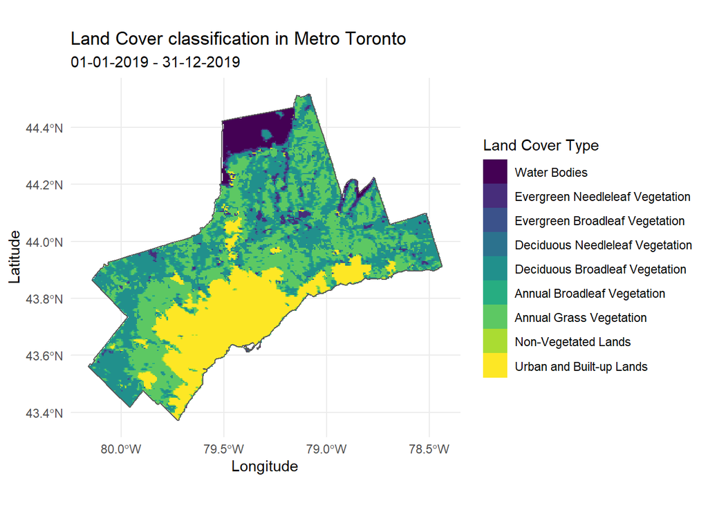

```r
ggplot() +
  geom_raster(data = BGC_df,
              aes(x = x, y = y, fill = MCD12Q1_LC4_2019_001)) +
  geom_sf(data = map_boundary, inherit.aes = FALSE, fill = NA) +
  scale_fill_viridis(name = "Land Cover Type", discrete = TRUE) +
  labs(title = "Land Cover classification in Metro Toronto",
       subtitle = "01-01-2019 - 31-12-2019",
       x = "Longitude",
       y = "Latitude") +
  theme_minimal()
```

## Urban Only Map

Selecting urban areas only for visualization. It should work better at a smaller scale.

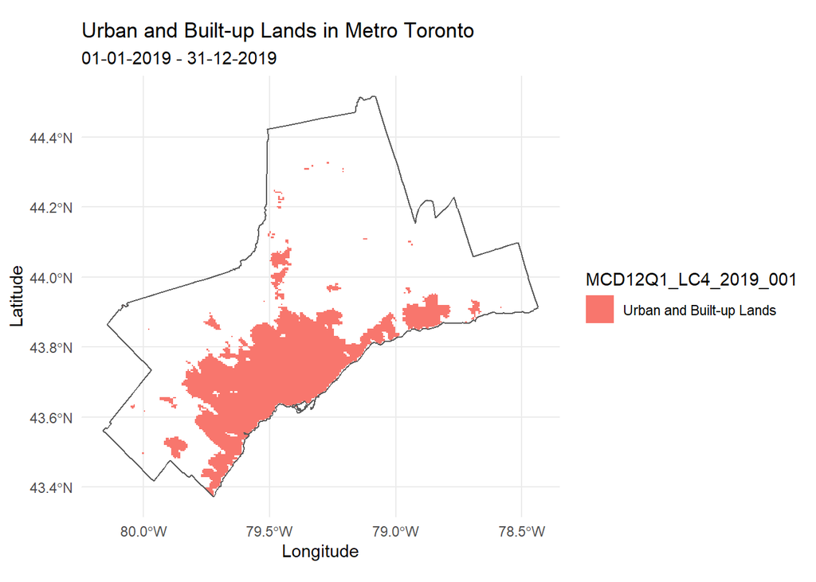

```r
BGC_df %>%
  filter(MCD12Q1_LC4_2019_001 == "Urban and Built-up Lands") %>%
  ggplot() +
    geom_raster(aes(x = x, y = y, fill = MCD12Q1_LC4_2019_001)) +
    geom_sf(data = map_boundary,
            inherit.aes = FALSE, fill = NA, size = 0.5) +
    labs(title = "Urban and Built-up Lands in Metro Toronto",
         subtitle = "01-01-2019 - 31-12-2019",
         x = "Longitude",
         y = "Latitude") +
    theme_minimal()
```

## Local Segregation

This section draws on the 2011 Canadian Census data. I manually downloaded the data from [CHASS](http://dc.chass.utoronto.ca.myaccess.library.utoronto.ca/census/ea.html) and wrangled it in R, but the process is not shown here. In a future version, I plan to use the [`cancensus`](https://cran.r-project.org/web/packages/cancensus/vignettes/cancensus.html) package.

Note that the data here include calculated segregation and diversity measures using the `segregation` and the `diverse` packages. `segregation` includes a local segregation measure that I’ve calculated at each CMA level. The diversity measures from `diverse` don’t include a larger scale comparison as they account for diversity within each tract. Also, I have limited the data to the five largest Census Metropolitan Areas (CMA): Toronto, Montreal, Vancouver, Ottawa-Gatineau, and Edmonton.

### Inspecting data

```r
(dat = read_csv("data/processed/ct01vmsegdiv11_n.csv")) |> head(10)
```

```
## # A tibble: 10 x 38
##      cma    ct01 vmtotal11  vm11 vmsasia11 vmchi11 vmblack11 vmfil11 vmla11
##    <dbl>   <dbl>     <dbl> <dbl>     <dbl>   <dbl>     <dbl>   <dbl>  <dbl>
##  1   462 4620001      2570   230         0       0       100       0     45
##  2   462 4620002      3040   340         0      25       115       0    115
##  3   462 4620003      6165   910        10      70       405       0    185
##  4   462 4620004      3175   405         0      30       170       0     95
##  5   462 4620005      3105   280         0      60        85       0     25
##  6   462 4620006      4405   835         0     130       310       0     40
##  7   462 4620007      5660  1145        20      70       340       0    315
##  8   462 4620008      2940   345         0      20       105       0     95
##  9   462 4620009      3375   455         0      25       120       0     95
## 10   462 4620010      1480   230        45       0        65       0     50
## # ... with 29 more variables: vmarab11 <dbl>, vmseasia11 <dbl>,
## #   vmwasia11 <dbl>, vmkorea11 <dbl>, vmjapan11 <dbl>, vmother11 <dbl>,
## #   vmmulti11 <dbl>, vmnot11 <dbl>, aboriginal11 <dbl>, abnot11 <dbl>,
## #   localseg_11 <dbl>, prop_11 <dbl>, variety_11 <dbl>, entropy_11 <dbl>,
## #   HHI_11 <dbl>, blau.index_11 <dbl>, gini.simpson_11 <dbl>,
## #   gini.simpson.C_11 <dbl>, gini.simpson.R_11 <dbl>, simpson.D_11 <dbl>,
## #   simpson.I_11 <dbl>, simpson.R_11 <dbl>, hill.numbers_11 <dbl>, ...
```

### Reading and merging spatial data

Note that I use 2001 census geographies. The reason is that this year allows better comparisons over time.

```r
# reading geography file (old one but works)
ct01sf = st_read("data/raw/cma5_ct01/cma5_ct01.shp") |>
  mutate(CT01 = as.numeric(CT01))
# merging data
ct01seg11sf = merge(ct01sf, dat, by.x="CT01", by.y="ct01", all.x=TRUE)
```

### Maps

Now, the maps. We want to compare a choropleth with a dasymetric map.

#### Local Segregation in Toronto CMA - Choropleth

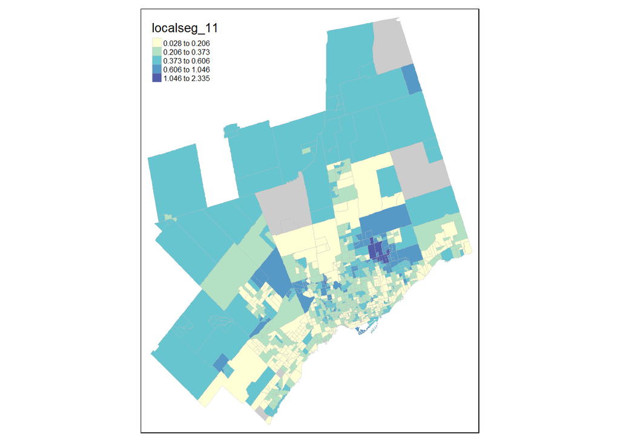

```r
pal = brewer.pal(5, "YlGnBu")
to_localseg_choro = ct01seg11sf %>%
  filter(CMAUID == "535") %>%
  st_transform(epgs=3857) %>%
  tm_shape() +
  tm_borders("Gray", lwd = .25, alpha = .4) +
  tm_fill(col = "localseg_11",
          alpha = .8,
          palette = pal,
          showNA = FALSE,
          style = "kmeans") +
tm_layout(legend.title.size = 1,
          legend.text.size = 0.5,
          legend.position = c("left","top"))
to_localseg_choro
```

#### Local Segregation in Toronto CMA - Dasymetric

First, we need to process the raster.

```r
# deleting non urban raster pixels
toronto_urban = BGC_raster
toronto_urban[!toronto_urban %in% 8] = NA

# projecting
toronto_urban = projectRaster(toronto_urban, crs = CRS("+proj=longlat +datum=WGS84 +no_defs"))
# tansform to xyz and sf object
toronto_urban <- as.data.frame(toronto_urban, xy = TRUE, na.rm = TRUE)
toronto_urban <- st_as_sf(toronto_urban, coords = c("x", "y"), crs = 4326)
toronto_urban <- toronto_urban %>% rename(urb = 1) %>%
  cbind(st_coordinates(toronto_urban))

# merging diversity and segregation data on spatial dots. Note that both objects are of `sf` type and projected with the same CRS.
to_localseg_points = st_join(toronto_urban, ct01seg11sf)
```

And now the map.

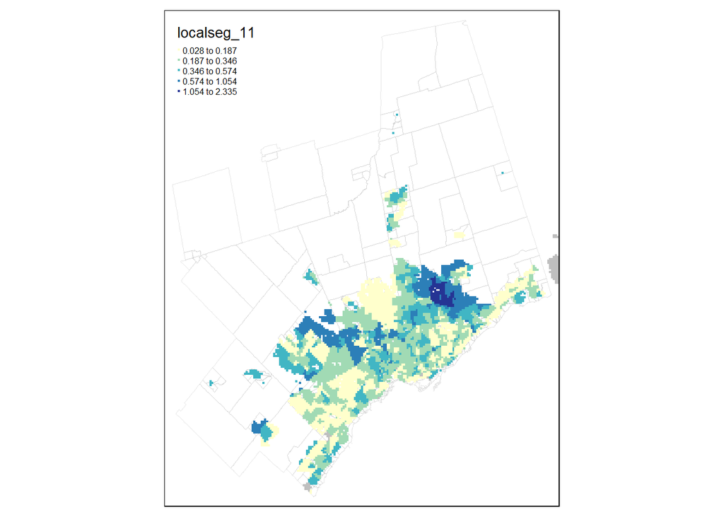

```r
pal = brewer.pal(5, "YlGnBu")
to_localseg_dasy = ct01seg11sf %>%
  filter(CMAUID == "535") %>%
  st_transform(epgs=3857) %>%
  tm_shape() +
  tm_borders("Gray", lwd = .25, alpha = .4) +
  tm_shape(to_localseg_points) +
  tm_dots(col = "localseg_11",
          palette = pal,
          showNA = FALSE,
          style = "kmeans") +
  tm_layout(legend.title.size = 1,
            legend.text.size = 0.5,
            legend.position = c("left","top"))
to_localseg_dasy
```

#### Comparison

Note that the scales are not the same in both graphs. The reason is that some tracts are not included in the k-means calculation for the dasymetric map. In a future version, I will create the breaks separatedly so that the comparison is more accurate.

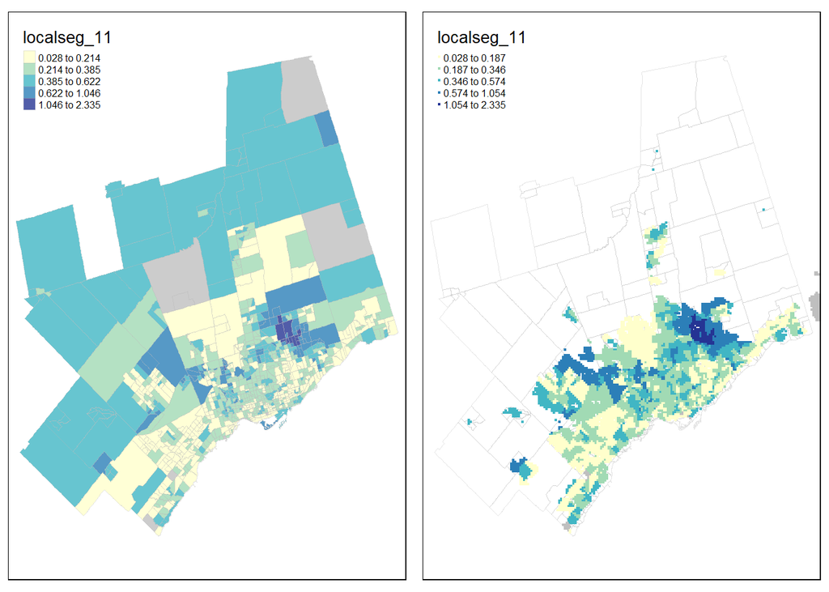

```r
tmap_arrange(to_localseg_choro, to_localseg_dasy)
```